# Bank Telemarketing

###**Data Loading and consolidation**

```
## 'data.frame':    41188 obs. of  21 variables:
##  $ AGE           : int  46 44 51 28 37 34 46 42 36 54 ...
##  $ JOB           : Factor w/ 12 levels "admin.","blue-collar",..: 5 8 1 8 2 10 2 2 1 2 ...
##  $ MARITAL       : Factor w/ 4 levels "divorced","married",..: 2 2 3 2 2 2 2 2 2 2 ...
##  $ EDUCATION     : Factor w/ 8 levels "basic.4y","basic.6y",..: 3 4 2 4 3 4 2 3 7 1 ...
##  $ DEFAULTCREDIT : Factor w/ 3 levels "no","unknown",..: 1 1 1 1 1 1 2 1 1 2 ...
##  $ HOUSING       : Factor w/ 3 levels "no","unknown",..: 1 3 1 3 1 1 3 3 3 1 ...
##  $ LOAN          : Factor w/ 3 levels "no","unknown",..: 1 3 1 1 1 1 1 3 1 1 ...
##  $ CONTACT       : Factor w/ 2 levels "cellular","telephone": 2 2 2 2 2 2 2 2 2 2 ...
##  $ MONTH         : Factor w/ 10 levels "apr","aug","dec",..: 7 7 7 7 7 7 7 7 7 7 ...
##  $ DAY_OF_WEEK   : Factor w/ 5 levels "fri","mon","thu",..: 2 2 2 2 2 2 2 2 2 2 ...
##  $ DURATION      : int  128 107 303 81 270 228 240 673 233 102 ...
##  $ CAMPAIGN      : int  2 1 2 1 1 1 1 2 3 1 ...
##  $ PDAYS         : int  999 999 999 999 999 999 999 999 999 999 ...
##  $ PREVIOUS      : int  0 0 0 0 0 0 0 0 0 0 ...
##  $ POUTCOME      : Factor w/ 3 levels "failure","nonexistent",..: 2 2 2 2 2 2 2 2 2 2 ...
##  $ EMP_VAR_RATE  : num  1.1 1.1 1.1 1.1 1.1 1.1 1.1 1.1 1.1 1.1 ...
##  $ CONS_PRICE_IDX: num  94 94 94 94 94 ...
##  $ CONS_CONF_IDX : num  -36.4 -36.4 -36.4 -36.4 -36.4 -36.4 -36.4 -36.4 -36.4 -36.4 ...
##  $ EURIBOR3M     : num  4.86 4.86 4.86 4.86 4.86 ...
##  $ NR_EMPLOYED   : num  5191 5191 5191 5191 5191 ...
##  $ Y             : Factor w/ 2 levels "no","yes": 1 1 1 1 1 1 1 2 1 1 ...
```

#####**Missing value and empty data imputation**

```
##            AGE            JOB        MARITAL      EDUCATION  DEFAULTCREDIT
##              0              0              0              0              0
##        HOUSING           LOAN        CONTACT          MONTH    DAY_OF_WEEK
##              0              0              0              0              0
##       DURATION       CAMPAIGN          PDAYS       PREVIOUS       POUTCOME
##              0              0              0              0              0
##   EMP_VAR_RATE CONS_PRICE_IDX  CONS_CONF_IDX      EURIBOR3M    NR_EMPLOYED
##              0              0              0              0              0
##              Y
##              0
```

```
##            AGE            JOB        MARITAL      EDUCATION  DEFAULTCREDIT
##              0              0              0              0              0
##        HOUSING           LOAN        CONTACT          MONTH    DAY_OF_WEEK
##              0              0              0              0              0
##       DURATION       CAMPAIGN          PDAYS       PREVIOUS       POUTCOME
##              0              0              0              0              0
##   EMP_VAR_RATE CONS_PRICE_IDX  CONS_CONF_IDX      EURIBOR3M    NR_EMPLOYED
##              0              0              0              0              0
##              Y
##              0
```

There are neither missing values nor empty data in our dataset

###**Exploratory analysis**

#####**Impact of Marital Status on Successful Telemarketing**

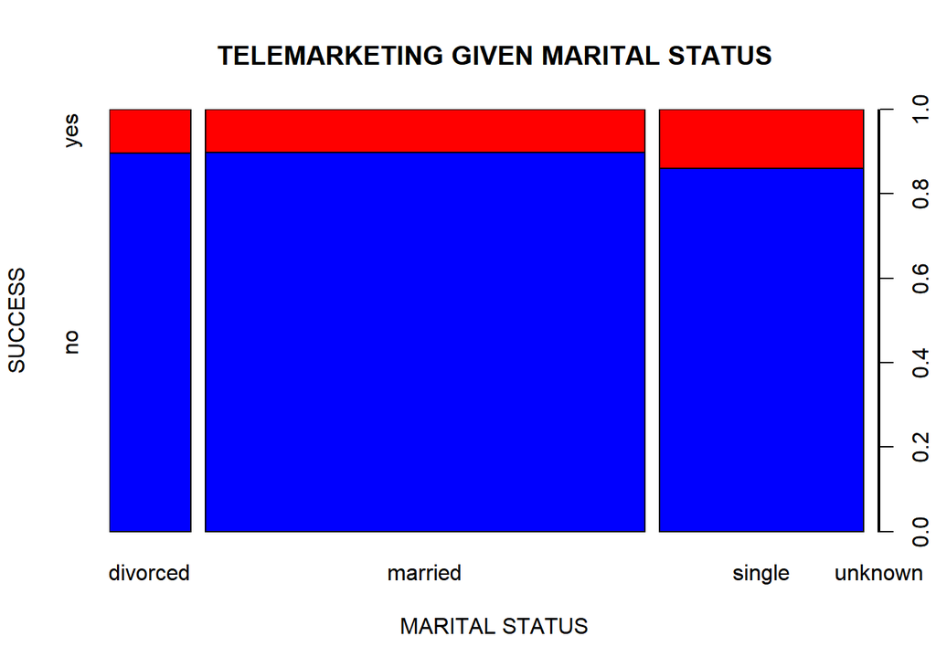

The proportion of unsuccessful telemarketing is almost similar for all categories.

#####**Impact of Level of Education on telemarketing success**

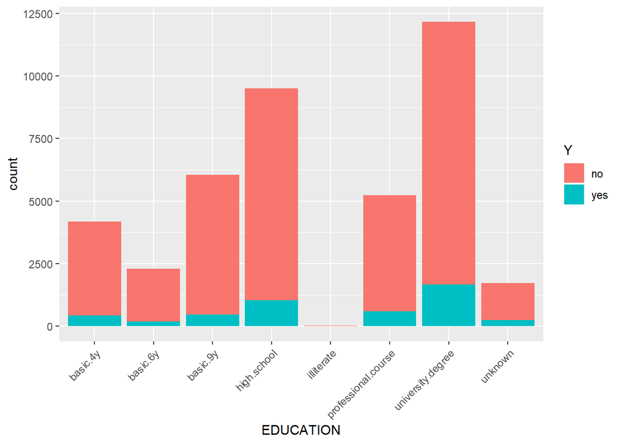

#####**Impact of Job type on telemarketing success**

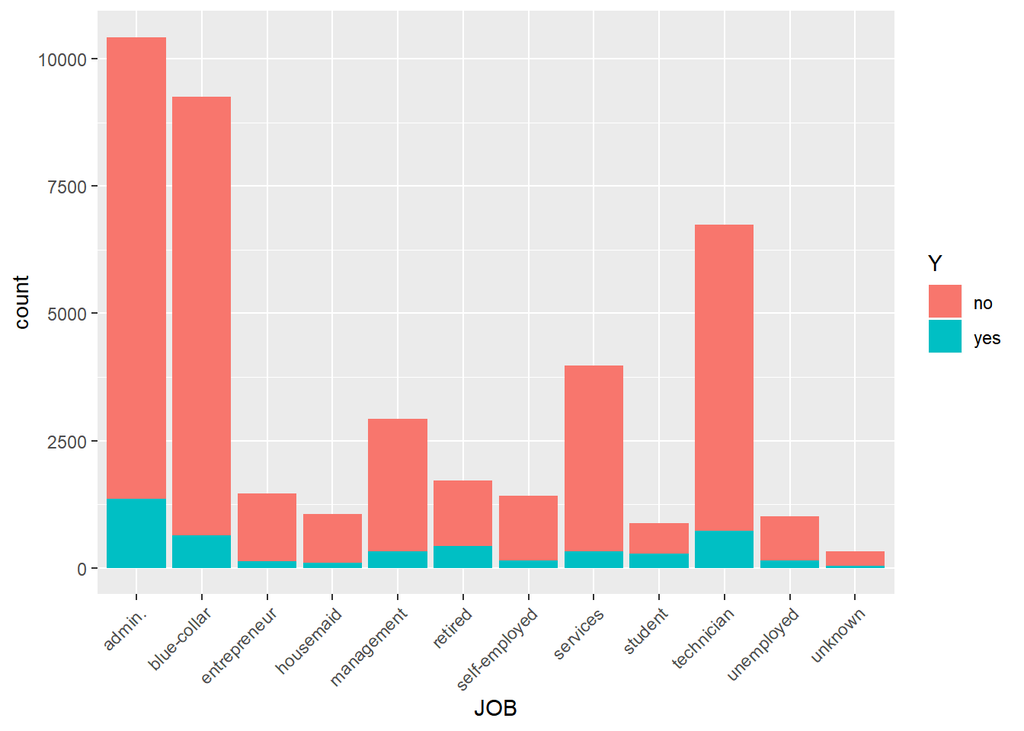

#####**Impact of Personal Loan on telemarketing success**

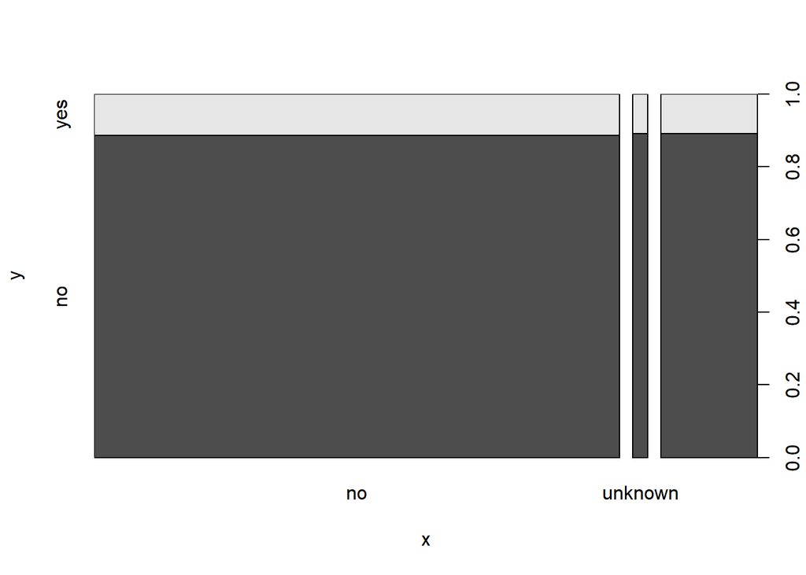

#####**Impact of Housing loan on telemarketing success**

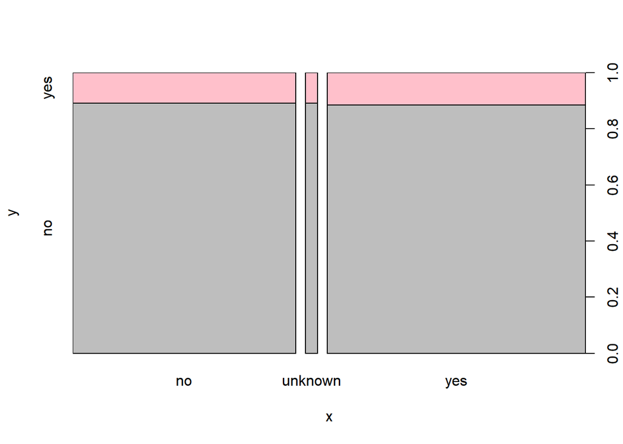

#####**Impact of Credit history on telemarketing success**

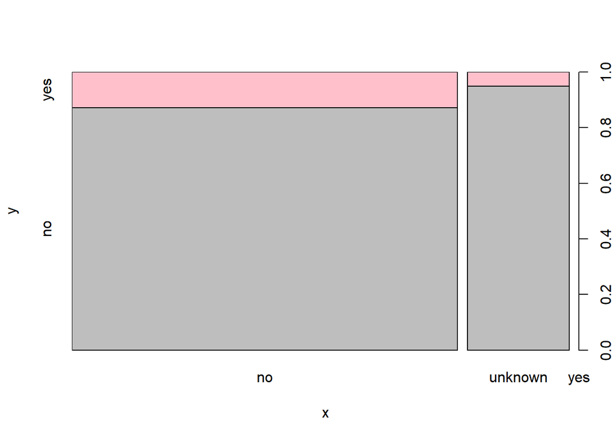

#####**Impact of Communication type on telemarketing success**

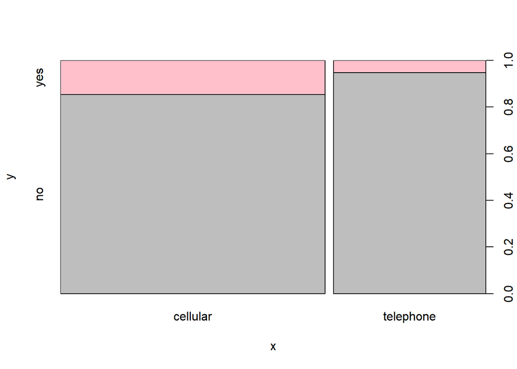

Partision the data into training and testing dataset

```r
Data %<>% select(-DURATION)
id <- createDataPartition(Data$Y,times = 1,p = 0.7,list = FALSE)
train <- Data[id,]
test <- Data[-id,]
```

####**Benchmark decision tree**

create benchmark model

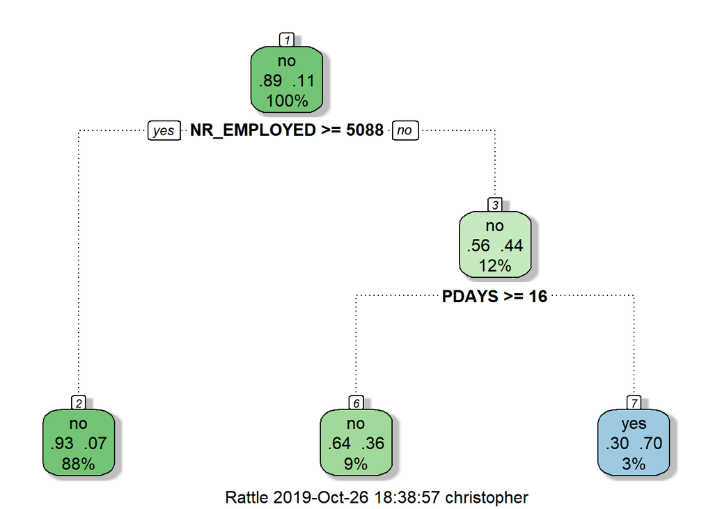

Let’s predict using the benchmark model

```
## Confusion Matrix and Statistics
##
##           Reference
## Prediction    no   yes
##        no  25324  2651
##        yes   260   597
##
##                Accuracy : 0.899
##                  95% CI : (0.8955, 0.9025)
##     No Information Rate : 0.8873
##     P-Value [Acc > NIR] : 9.791e-11
##
##                   Kappa : 0.2559
##
##  Mcnemar's Test P-Value : < 2.2e-16
##
##             Sensitivity : 0.9898
##             Specificity : 0.1838
##          Pos Pred Value : 0.9052
##          Neg Pred Value : 0.6966
##              Prevalence : 0.8873
##          Detection Rate : 0.8783
##    Detection Prevalence : 0.9703
##       Balanced Accuracy : 0.5868
##
##        'Positive' Class : no
##
```

There is chance of overfitting in Single tree, So I will go for cross validation using n fold techinque

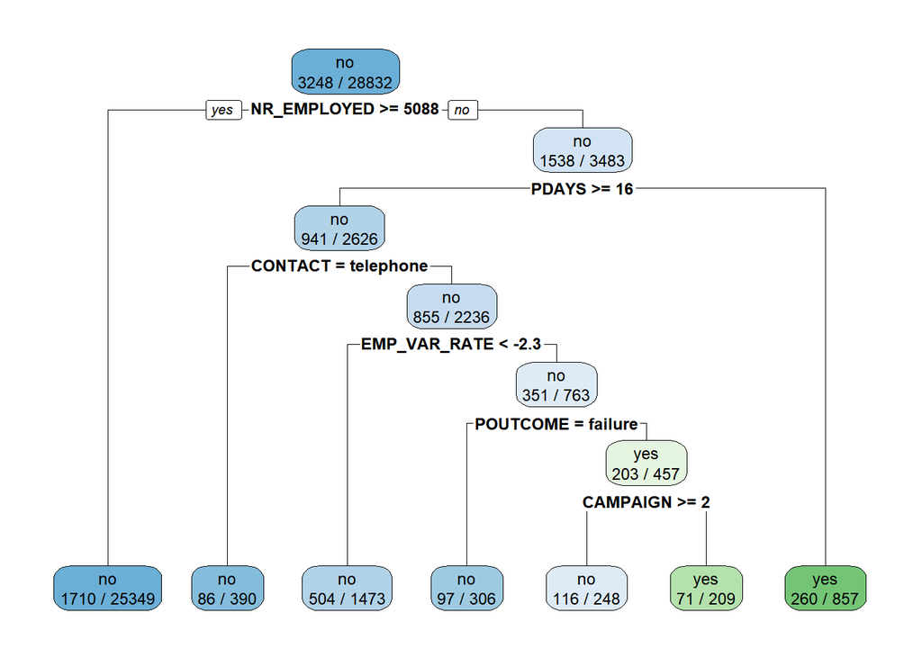

```
## Confusion Matrix and Statistics
##
##           Reference
## Prediction    no   yes
##        no  25253  2513
##        yes   331   735
##
##                Accuracy : 0.9014
##                  95% CI : (0.8979, 0.9048)
##     No Information Rate : 0.8873
##     P-Value [Acc > NIR] : 9.491e-15
##
##                   Kappa : 0.3019
##
##  Mcnemar's Test P-Value : < 2.2e-16
##
##             Sensitivity : 0.9871
##             Specificity : 0.2263
##          Pos Pred Value : 0.9095
##          Neg Pred Value : 0.6895
##              Prevalence : 0.8873
##          Detection Rate : 0.8759
##    Detection Prevalence : 0.9630
##       Balanced Accuracy : 0.6067
##
##        'Positive' Class : no
##
```

```
## Confusion Matrix and Statistics
##
##           Reference
## Prediction    no   yes
##        no  10845  1099
##        yes   119   293
##
##                Accuracy : 0.9014
##                  95% CI : (0.896, 0.9066)
##     No Information Rate : 0.8873
##     P-Value [Acc > NIR] : 2.483e-07
##
##                   Kappa : 0.2882
##
##  Mcnemar's Test P-Value : < 2.2e-16
##
##             Sensitivity : 0.9891
##             Specificity : 0.2105
##          Pos Pred Value : 0.9080
##          Neg Pred Value : 0.7112
##              Prevalence : 0.8873
##          Detection Rate : 0.8777
##    Detection Prevalence : 0.9667
##       Balanced Accuracy : 0.5998
##
##        'Positive' Class : no
##
```